# Transformer

Let's implement simple transformer using PyTorch!

```python
import torch
import torch.nn as nn
from torch.nn import functional as fn
from tqdm import tqdm

import math
from importlib import reload

torch.manual_seed(1337)
```

```
<torch._C.Generator at 0x1f7b3694f30>
```

If you have cuda available on your machine, then let's take advantage of it to help make the computation go faster.

```python
device = 'cuda' if torch.cuda.is_available() else 'cpu'
device
```

```
'cuda'
```

Let's set some configurations for the neural network.

```python
class Config():
    def __init__(self, context_size, batch_size,
        n_blocks=1, n_heads=2, embed_size=8, weight_tying=False):
        self.n_blocks = n_blocks
        self.n_heads = n_heads
        self.embed_size = embed_size
        self.context_size = context_size
        self.batch_size = batch_size
        self.weight_tying = weight_tying
```

```python
config = Config(
    context_size = 16,
    batch_size = 128,
    n_blocks = 1,
    n_heads = 2,
    embed_size = 8,
    weight_tying = False,
)
```

The preprocessing is somewhat involved. If you wish to see how this is done, you can examine `utils/preprocess.py` to see how this is done.

Transformers have a fixed context size, so if our sequences are too short, we must pad them. One reasonable choice is to pad the sequence on the left with our token for marking the start of a sequence `^`.

We also add a termination token `$` to mark the end of each sequence.

Because we are serious about machine learning, we always split our data at least into training and testing before we start training.

```python
import utils.preprocess as pp
reload(pp)

dataset = pp.ShortSequenceDataset('data/restriction-sites.txt',
    context_size=config.context_size, batch_size=config.batch_size
).to(device)

config.vocab_size = len(dataset.vocab)
config.init_code = dataset.init_code

data_train, data_test = torch.utils.data.random_split(dataset, [0.9, 0.1])

(len(data_train), len(data_test))
```

```
(411, 45)
```

Let's examine the first three sample. Each sample consists of the encoded sequence, as well as the targets to be predicted.

```python
data_train[0:3]
```

```
(tensor([[30, 30, 30, 30, 30, 30, 30, 19, 19,  4, 17, 19, 17, 19, 17, 17],
         [30, 30, 30, 30, 30, 30, 17, 26, 17, 15, 19,  1, 14,  4, 12,  2],
         [30, 30, 30, 30, 30, 30, 30, 30, 30, 19, 26, 23,  4, 23, 15, 17]],
        device='cuda:0'),
 tensor([[30, 30, 30, 30, 30, 30, 19, 19,  4, 17, 19, 17, 19, 17, 17,  0],
         [30, 30, 30, 30, 30, 17, 26, 17, 15, 19,  1, 14,  4, 12,  2,  0],
         [30, 30, 30, 30, 30, 30, 30, 30, 19, 26, 23,  4, 23, 15, 17,  0]],
        device='cuda:0'))
```

In this exercise, we are interested in next-token prediction, so the target which is just the encoded sequence right-shifted. We can see this by decoding one of the sample sequence and the target.

```python
print(dataset.decode(dataset[7][0]))
print(dataset.decode(dataset[7][1]))
```

```
^^^^^^^^^A/CCGGT
^^^^^^^^A/CCGGT$
```

Layer Normalization

```python
class LayerNorm(nn.Module):
    def __init__(self, features, eps=1e-6):
        super().__init__()
        self.gain = nn.Parameter(torch.ones(features))
        self.bias = nn.Parameter(torch.zeros(features))
        self.eps = eps

    def forward(self, X):
        mean = X.mean(-1, keepdim=True)
        std = X.std(-1, keepdim=True)
        return self.gain * (X - mean) / (std + self.eps) + self.bias

class Block(nn.Module):
    def __init__(self, config):
        super().__init__()
        self.ln1 = LayerNorm(config.embed_size)
        self.attend = Attention(config)
        self.ln2 = LayerNorm(config.embed_size)
        self.feed = Feedforward(config)

    def forward(self, X):
        X = X + self.attend(self.ln1(X))
        X = X + self.feed(self.ln2(X))
        return X
```

Now, we are ready to start implementing our transformer!

Each transfomer block consists of an attention module, followed by a feedforward module.

The feedforward module is a **feedforward neural network** with one hidden layer and one output layer (which is also known as a **multilayer perceptron**.) The hidden layer in our network uses the **Gaussian Error Linear Unit** (GELU) transfer function. Other common transfer functions include the **Rectified Linear Unit** (RELU) and the **sigmoid function**.

The **multihead attention** module in the transformer architecture allows each token embedding to be contextualized by the embeddings of other tokens, using attention mechanism.

```python
class Block(nn.Module):
    def __init__(self, config):
        super().__init__()
        self.ln1 = LayerNorm(config.embed_size)
        self.attend = Attention(config)
        self.ln2 = LayerNorm(config.embed_size)
        self.feed = Feedforward(config)

    def forward(self, X):
        X = X + self.attend(self.ln1(X))
        X = X + self.feed(self.ln2(X))
        return X

class Attention(nn.Module):
    """
    Masked multi-head attention.
    """

    def __init__(self, config):
        super().__init__()
        self.config = config
        self.ln = LayerNorm(config.embed_size)  # Layer normalization initialization
        embed_size = config.embed_size
        context_size = config.context_size
        # key, query, value projections for all attention heads
        self.kqv = nn.Linear(embed_size, 3*embed_size, bias=False)
        # output projection
        self.output = nn.Linear(embed_size, embed_size, bias=False)
        # mask out upper diagonal
        self.register_buffer("mask", torch.tril(torch.ones(context_size, context_size))
            .view(1, 1, context_size, context_size))

    def forward(self, X):
        X = self.ln(X) # layer normalization
        # batch size, sequence length, and embedding dimensionality
        B, T, D = X.shape

        embed_size = self.config.embed_size
        n_heads = self.config.n_heads

        # (B, D, 3*D)  -> (B, D, D)
        # multiple each weight matrix with data and split
        query, key, value = self.kqv(X).split(embed_size, dim=2)
        # (B, D, D) -> (B, H, T, D/H)
        key = key.view(B, T, n_heads, D // n_heads).transpose(1, 2)
        query = query.view(B, T, n_heads, D // n_heads).transpose(1, 2)
        value = value.view(B, T, n_heads, D // n_heads).transpose(1, 2)

        # (B, H, T, D/H) @ (B, H, D/H, T) -> (B, H, T, T)
        att = (query @ key.transpose(-2, -1)) / math.sqrt(key.size(-1))
        att = att.masked_fill(self.mask[:, :, :T, :T] == 0, float('-inf'))
        att = fn.softmax(att, dim=-1)

        # (B, H, T, T) @ (B, H, T, D/H) -> (B, H, T, D/H)
        Y = att @ value

        # re-assemble outputs from all heads
        Y = Y.transpose(1, 2).contiguous().view(B, T, D)

        # linear map of all heads together
        Y = self.output(Y)
        return Y

class Feedforward(nn.Module):
    """
    Feedforward network.
    """

    def __init__(self, config):
        super().__init__()
        self.ln = LayerNorm(config.embed_size)  # Layer normalization initialization
        self.config = config
        embed_size = config.embed_size
        self.hidden = nn.Linear(embed_size, 4*embed_size)
        self.gelu = nn.GELU()
        self.output = nn.Linear(4*embed_size, embed_size)

    def forward(self, X):
        X = self.ln(X) # layer normalization
        X = self.hidden(X)
        X = self.gelu(X)
        X = self.output(X)
        return X
```

Now that the transformer block is implemented, we now implement GPT model.

```python
class GPT(nn.Module):

    def __init__(self, config):
        super().__init__()
        self.config = config
        self.token_embed = nn.Embedding(config.vocab_size, config.embed_size)
        self.pos_embed = nn.Embedding(config.context_size, config.embed_size)
        self.blocks = nn.ModuleList([Block(config) for _ in range(config.n_blocks)])
        if not config.weight_tying:
            self.unembed = nn.Linear(config.embed_size, config.vocab_size, bias=False)

    def forward(self, X, Y=None):
        # X is (B, T), Y is (B, T)
        pos = torch.arange(0, X.shape[1], dtype=torch.long).to(device)

        token_embeds = self.token_embed(X)
        pos_embeds = self.pos_embed(pos)
        embeds = token_embeds + pos_embeds

        for block in self.blocks:
            embeds = block(embeds)

        if config.weight_tying:
            # tie the unembedding weights to the embedding weights
            # linear function transposes the weight
            logits = fn.linear(embeds, self.token_embed.weight) # (B, T, C)
        else:
            logits = self.unembed(embeds)  # (B, T, C)

        if Y is None:
            loss = None
        else:
            B, T, C = logits.shape
            logits = logits.view(B*T, C)
            Y = Y.view(B*T)
            loss = fn.cross_entropy(logits, Y)

        return logits, loss

    @torch.no_grad()
    def sample(self, size, n=1, X=None, temperature=1.0):
        """
        Generate n new sequences of specified size given context X.
        """
        if X is None:
            X = (torch.tensor([[config.init_code]])
                .repeat(n, 1).to(device))
        for _ in range(size):
            if X.size(1) > self.config.context_size:
                # sequence context is too long; crop it to context_size
                X_cropped = X[:, -self.config.context_size:]
            else:
                X_cropped = X
            # get prediction
            logits, _ = self(X_cropped)
            # get last time step and scale by temperature
            logits = logits[:, -1, :] / temperature
            probs = fn.softmax(logits, dim=1)  # (B, C)
            x_new = torch.multinomial(probs, num_samples=1)
            X = torch.cat((X, x_new), dim=1)   # (B, T+1)
        return X
```

Phew! That was a lot of code.

Now, it is time to take our GPT model for a test drive!

```python
model = GPT(config).to(device)
```

Before training, our model has high loss, and it generates nonsensical sequence. We'll forgive our model, since it has not been trained on data yet.

```python
X0, y0 = data_train[0:3]
logits, loss = model(X0, y0)

print(loss)
dataset.decode( model.sample(16, n=10), strip=True)
```

```
tensor(3.4662, device='cuda:0', grad_fn=<NllLossBackward0>)
```

```
['58W6MTS9DR9-G5A2',
 '50-M63K3/K/Y6/2',
 'G)04T37WNKD7',
 '5((BH7)TG/(6N9',
 'G-TC-N(M45YS_1',
 '8V26V3)KHSD94415',
 'YBKM0TKYCC6-_V)N',
 '(B/6VW)6WNK40G',
 'V/19DN4-(MKC0-TG',
 'W_BBV-3(GWVCR_8S']
```

Our data has been preprocessed. Our model has been implemented and instantiated. Now, all that is left to do is to train our model. Yippee!

```python
import utils.train as tr
reload(tr)

optim = torch.optim.AdamW(model.parameters(), lr=1e-4)

model, losses_train, losses_test = tr.train(model, optim,
    data_train, data_test, config, n_epochs=1500)
```

Now's the moment we've all been waiting for... how well does our trained model do?

```python
print(f"loss: (train: {losses_train[-1]}, test: {losses_test[-1]})")
dataset.decode( model.sample(16, n=10), strip=True)
```

```
loss: (train: 0.9977558255195618, test: 1.0156176090240479)
```

```
['G/NGGA',
 'CCGC/N/CA/',
 'G/GNGG',
 'TG/GGN',
 'CT/G/(14/-2)',
 '/CTAC',
 'CCT/GGT',
 'GCWACGA',
 'CNGTCMCCTAT',
 'G/CCRGC']
```

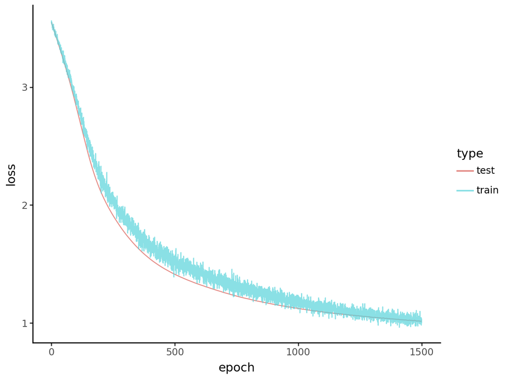

```python
from utils.plot import plot_loss # Weight Tying = False, With Layer Normalization

plot_loss(losses_train, losses_test)
```

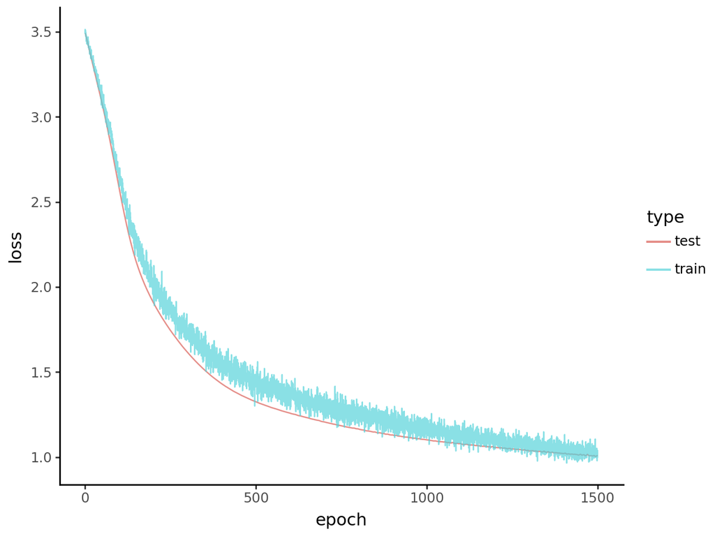

```python
from utils.plot import plot_loss # Weight Tying = False, No Layer Normalization

plot_loss(losses_train, losses_test)
```

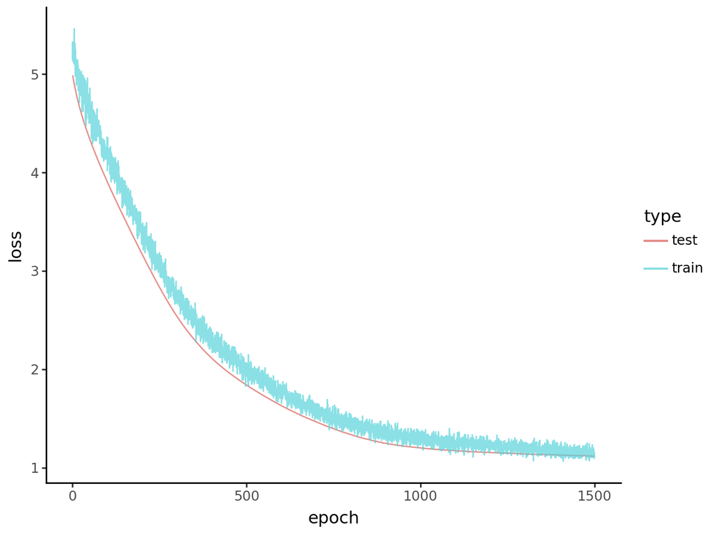

```python
from utils.plot import plot_loss # Weight Tying = TRUE, No Layer Normalization

plot_loss(losses_train, losses_test)
```

### Questions

1. How well does our model do after 50 epochs of training? How can we do better?
2. Play with the config values (hyperparameters). How can you improve the model performance?
3. What can you conclude from the training and test losses for a model with vs. without weight tying? (Hint: You will need to run at least 1000 epochs.)

A1. (Before any parameter tuning)  
After 50 epochs of training, the model shows a consistent decrease in loss for both the training and test datasets, which shows that the model is learning and generalizing well to the unseen data. As the curve converges, it indicates that the model is not overfitting significantly up to that point since the test loss follows the train loss closely without a large gap between them.

Modifying the parameters can improve the model. Different learning rates, batch sizes, and numbers of attention heads or layers in the model can improve (or decrease) the performance. Essentially, trial and error is needed to find the best parameters. We could apply regularization techniques, which could improve performance and prevent overfitting. Also, as for training any model, data is essential. Hence, we can consider improving the preprocessing and performing data augmentation for better results.

A2. (Testing done at 150 Epochs)

- Increasing the context size from 16 to 32 imrpoved perofmance by roughly 50%, changing it from 32 to 64 was another 50% improvement and the same was for increasing the context size from 64 to 128.
- Increasing the number of transformer blocks (n_blocks) or the size of embeddings (embed_size) to allow the model to capture more complex patterns. (Increasing the number of blocks from 1 to 2 and the embed_size from 8 to 16 improved the perfomance by roughly 25%, but this did increase computation time by alot.)
- The batch size is also a important factor, decreasing the size led to much better results but increased time to train by alot. (Roughly a 80% improvement by chaning the batch size from 128 to 4).
- Lastly, weight_tying, which involves reusing the same weights for different model parts (Will test for next question).

```
Initial (Provided Parameters):
loss: (train: 2.2331225872039795, test: 2.1473934650421143)
After New Parameters:
loss: (train: 0.12176791578531265, test: 0.11987825483083725)
```

Note: The 'Plot Loss' Graph showed that after each tweak to the paramters and improving the models perfomance overall showed that the change between epoch 50 to 150 was not that significiant.

*Final hyperparameters I chose:*

```
config = Config(
    context_size = 128,
    batch_size = 4,
    n_blocks = 2,
    n_heads = 2,
    embed_size = 16,
    weight_tying = False, # To be tested
)
```

A3. (Note: To save time I tweaked the hyperparameters to decrease computation time (I used the provided values). Total epochs in both cases used 1500).

*Hyperparameters Used*

```
config = Config(
    context_size = 16,
    batch_size = 128,
    n_blocks = 1,
    n_heads = 2,
    embed_size = 8,
    weight_tying = False/True,
)
```

```
weight_tying = False
loss: (train: 0.9979055523872375, test: 1.0084545612335205)

weight_tying = True
loss: (train: 1.1580454111099243, test: 1.1179149150848389)
```

With Weight Tying the training and test loss both start higher and end higher after 1500 epochs compared to the model without weight tying. The loss curves are smooth and demonstrate good generalization, as the test loss closely follows the training loss, suggesting that the model is learning patterns applicable to both the training and unseen data. Similarly to the model with weight tying, the loss curves here also show a good fit, with test loss closely following the training loss. The close proximity of the training and test loss curves in both graphs suggests that the models are generalizing well and are not overfitting.

### Bonus questions

1. Compared against the [transformer paper](https://arxiv.org/abs/1706.03762), our transformer is missing a few things. Implement the layer normalization and see how the model performs. (Hint: It is now known that implementing layer normalization **before** each of the attention and feedforward modules rather than after could produce more performant models.)
2. The transformer paper also uses drop-out layers. Add them to the model.

Bonus A1. (Note: Default Parameters Used.)

```
No Normalization
loss: (train: 0.9979055523872375, test: 1.0084545612335205)
With Normalization
loss: (train: 0.9977558255195618, test: 1.0156176090240479)
```

The graphs show that both models with and without layer normalization have learned effectively, as evidenced by the decreasing loss over epochs. The layer normalization seems to have a minimal effect on the training loss but doesn't improve the test loss in this particular case. This can be because the model architecture and/or the dataset already enables stable training so that the addition of layer normalization doesn't have a significant effect.